# **Principal Component Analysis**

```r
human <- read.table("http://s3.amazonaws.com/assets.datacamp.com/production/course_2218/datasets/human2.txt", sep=",", header=TRUE)

# Accesss necessary library
library(dplyr)
```

```r
library(ggplot2)
library(GGally)
```

Data structure

```r
# Structure
str(human)
```

```
## 'data.frame':    155 obs. of  8 variables:
##  $ Edu2.FM  : num  1.007 0.997 0.983 0.989 0.969 ...
##  $ Labo.FM  : num  0.891 0.819 0.825 0.884 0.829 ...
##  $ Edu.Exp  : num  17.5 20.2 15.8 18.7 17.9 16.5 18.6 16.5 15.9 19.2 ...
##  $ Life.Exp : num  81.6 82.4 83 80.2 81.6 80.9 80.9 79.1 82 81.8 ...
##  $ GNI      : int  64992 42261 56431 44025 45435 43919 39568 52947 42155 32689 ...
##  $ Mat.Mor  : int  4 6 6 5 6 7 9 28 11 8 ...
##  $ Ado.Birth: num  7.8 12.1 1.9 5.1 6.2 3.8 8.2 31 14.5 25.3 ...
##  $ Parli.F  : num  39.6 30.5 28.5 38 36.9 36.9 19.9 19.4 28.2 31.4 ...
```

```r
# Dimension
dim(human)
```

```
## [1] 155   8
```

```r
head(human)
```

```
##               Edu2.FM   Labo.FM Edu.Exp Life.Exp   GNI Mat.Mor Ado.Birth
## Norway      1.0072389 0.8908297    17.5     81.6 64992       4       7.8
## Australia   0.9968288 0.8189415    20.2     82.4 42261       6      12.1
## Switzerland 0.9834369 0.8251001    15.8     83.0 56431       6       1.9
## Denmark     0.9886128 0.8840361    18.7     80.2 44025       5       5.1
## Netherlands 0.9690608 0.8286119    17.9     81.6 45435       6       6.2
## Germany     0.9927835 0.8072289    16.5     80.9 43919       7       3.8
##             Parli.F
## Norway         39.6
## Australia      30.5
## Switzerland    28.5
## Denmark        38.0
## Netherlands    36.9
## Germany        36.9
```

Summarise Data

```r
summary(human)
```

```
##     Edu2.FM          Labo.FM          Edu.Exp         Life.Exp
##  Min.   :0.1717   Min.   :0.1857   Min.   : 5.40   Min.   :49.00
##  1st Qu.:0.7264   1st Qu.:0.5984   1st Qu.:11.25   1st Qu.:66.30
##  Median :0.9375   Median :0.7535   Median :13.50   Median :74.20
##  Mean   :0.8529   Mean   :0.7074   Mean   :13.18   Mean   :71.65
##  3rd Qu.:0.9968   3rd Qu.:0.8535   3rd Qu.:15.20   3rd Qu.:77.25
##  Max.   :1.4967   Max.   :1.0380   Max.   :20.20   Max.   :83.50
##       GNI            Mat.Mor         Ado.Birth         Parli.F
##  Min.   :   581   Min.   :   1.0   Min.   :  0.60   Min.   : 0.00
##  1st Qu.:  4198   1st Qu.:  11.5   1st Qu.: 12.65   1st Qu.:12.40
##  Median : 12040   Median :  49.0   Median : 33.60   Median :19.30
##  Mean   : 17628   Mean   : 149.1   Mean   : 47.16   Mean   :20.91
##  3rd Qu.: 24512   3rd Qu.: 190.0   3rd Qu.: 71.95   3rd Qu.:27.95
##  Max.   :123124   Max.   :1100.0   Max.   :204.80   Max.   :57.50
```

```r
# glimpse at the human data
glimpse(human)
```

```
## Rows: 155
## Columns: 8
## $ Edu2.FM   <dbl> 1.0072389, 0.9968288, 0.9834369, 0.9886128, 0.969060...
## $ Labo.FM   <dbl> 0.8908297, 0.8189415, 0.8251001, 0.8840361, 0.828611...
## $ Edu.Exp   <dbl> 17.5, 20.2, 15.8, 18.7, 17.9, 16.5, 18.6, 16.5, 15.9...
## $ Life.Exp  <dbl> 81.6, 82.4, 83.0, 80.2, 81.6, 80.9, 80.9, 79.1, 82.0...
## $ GNI       <int> 64992, 42261, 56431, 44025, 45435, 43919, 39568, 529...
## $ Mat.Mor   <int> 4, 6, 6, 5, 6, 7, 9, 28, 11, 8, 6, 4, 8, 4, 27, 2, 1...
## $ Ado.Birth <dbl> 7.8, 12.1, 1.9, 5.1, 6.2, 3.8, 8.2, 31.0, 14.5, 25.3...
## $ Parli.F   <dbl> 39.6, 30.5, 28.5, 38.0, 36.9, 36.9, 19.9, 19.4, 28.2...
```

Explore relationships

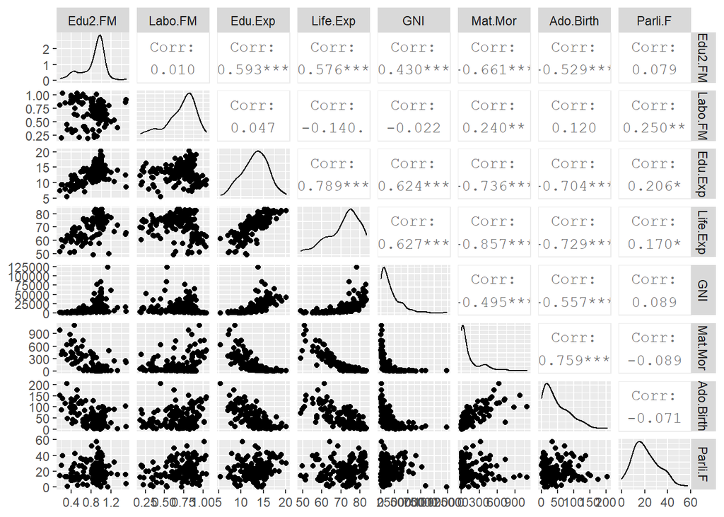

```r
# Access GGally
library(GGally)

# To visualise the correlation between the variables in our data
ggpairs(human)
```

The diagonal plots give the density plot. The scale of the y axis is printed on the left side of the matrix and x axis is at the bottom of the matrix.

Variable that are significantly positive or significantly negative are give by the symbol (***)

The plot below the density plot shows the scatter plot between two variables

We can also look at the correlations using the cor from the *corrplot function*

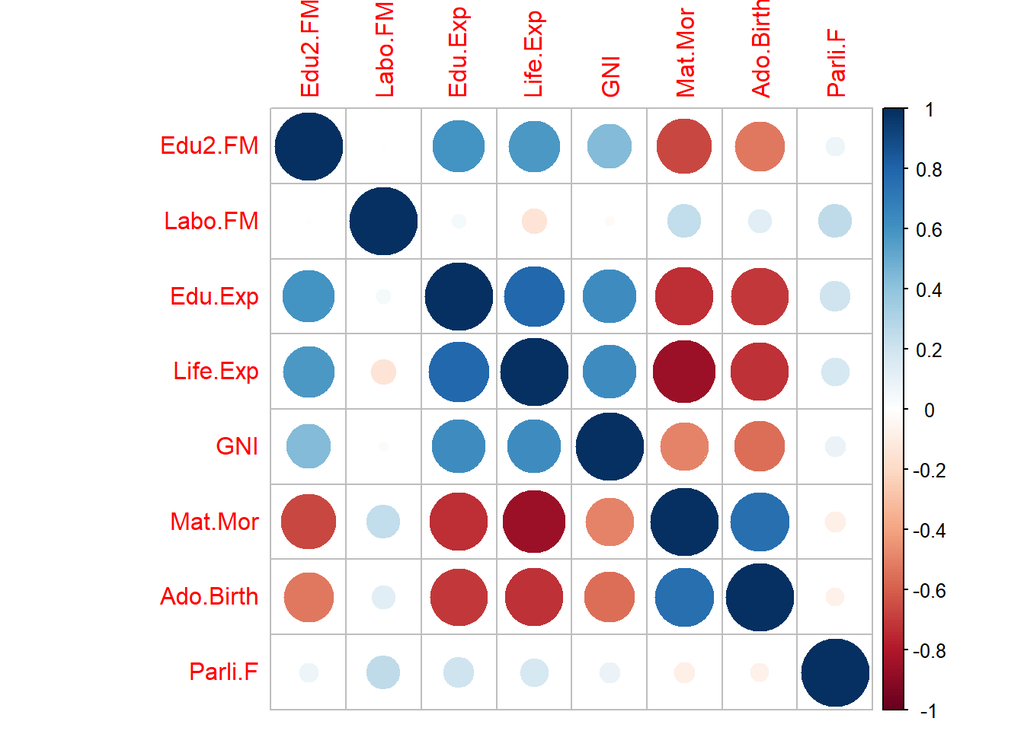

```r
# Access corrplot
library(corrplot)
# compute the correlation matrix and visualize it with corrplot
cor(human) %>% corrplot
```

**Principal Component Analysis (PCA)**

Principal Component Analysis a method used to reduce the dimensionality of large data sets into a smaller one that still contains most of the information in the large set.

The number of PCs is equal to the number of original variables and for our case we have eight (8).

The aim is to keep only the PCs that explain the most variance of our data to make the interpretation easier.

**PCA on Unstandardise data**

```r
# perform principal component analysis (with the SVD method)
pca_human1 <- prcomp(human)
summary(pca_human1)
```

```
## Importance of components:
##                              PC1      PC2   PC3   PC4   PC5   PC6    PC7
## Standard deviation     1.854e+04 185.5219 25.19 11.45 3.766 1.566 0.1912
## Proportion of Variance 9.999e-01   0.0001  0.00  0.00 0.000 0.000 0.0000
## Cumulative Proportion  9.999e-01   1.0000  1.00  1.00 1.000 1.000 1.0000
##                           PC8
## Standard deviation     0.1591
## Proportion of Variance 0.0000
## Cumulative Proportion  1.0000
```

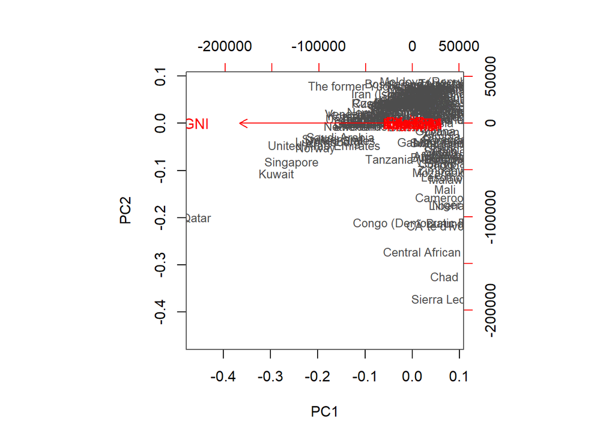

```r
# draw a biplot of the principal component representation and the original variables
biplot(pca_human1, choices = 1:2, cex = c(0.8, 1),col = c("grey30", "red"))
```

```r
# Access the factoextra
library(factoextra)
```

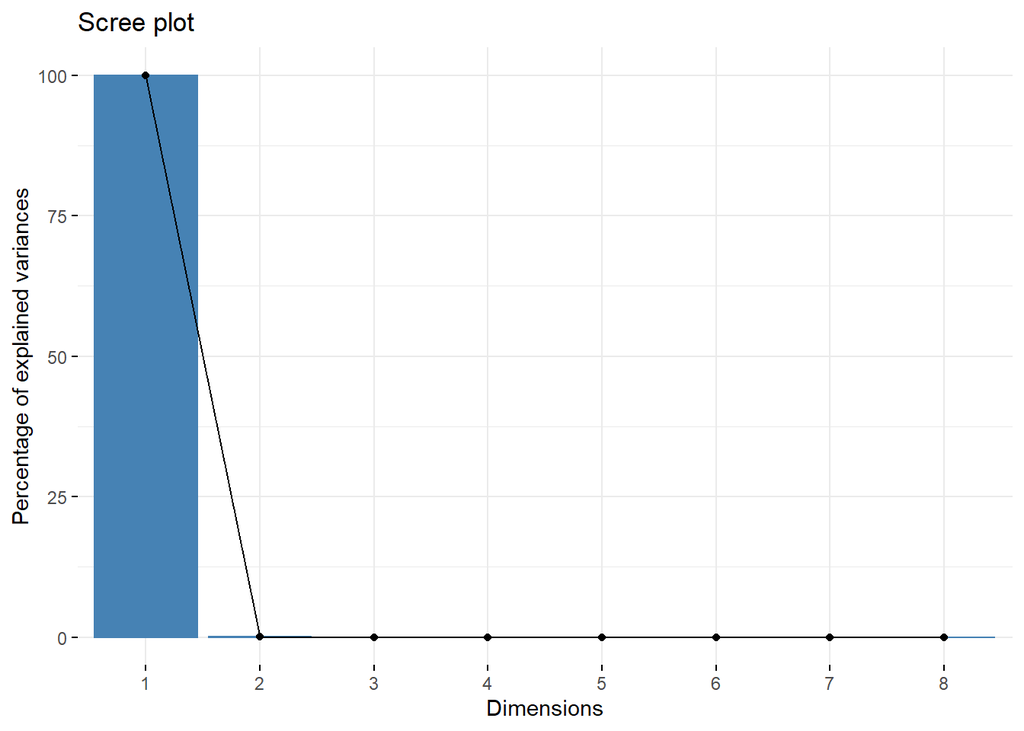

```r
#Visualize eigenvalues
fviz_eig(pca_human1)
```

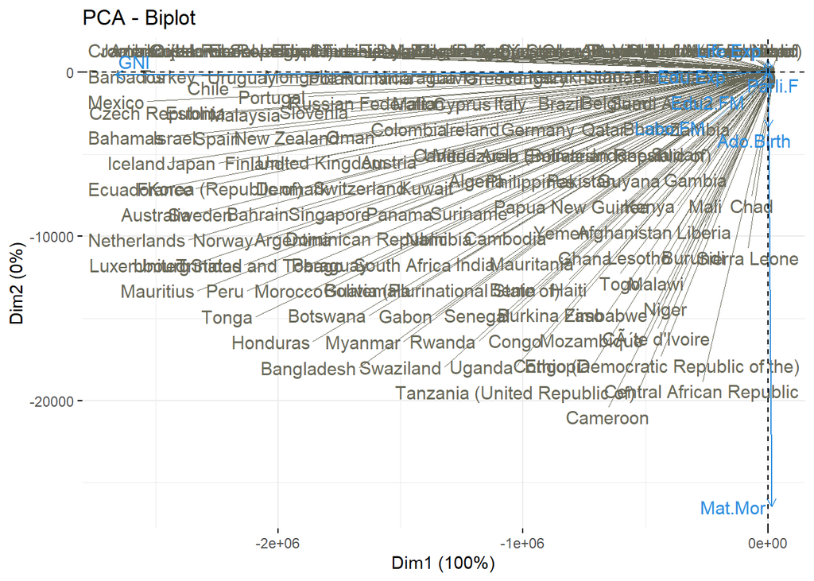

```r
# Another way to draw a biplot of the principal component
# Gives percentage variance of PC1 on the x axis and PC2 on the y axis
fviz_pca_biplot(pca_human1, repel = TRUE, col.var = "#2E8FDF", # Variables color
                col.ind = "#696959"  # Individuals color
                )
```

```r
eig.val <- get_eigenvalue(pca_human1)
eig.val
```

```
##         eigenvalue variance.percent cumulative.variance.percent
## Dim.1 3.438860e+08     9.998976e+01                    99.98976
## Dim.2 3.441836e+04     1.000763e-02                    99.99977
## Dim.3 6.343853e+02     1.844566e-04                    99.99996
## Dim.4 1.312035e+02     3.814929e-05                   100.00000
## Dim.5 1.418457e+01     4.124367e-06                   100.00000
## Dim.6 2.452081e+00     7.129774e-07                   100.00000
## Dim.7 3.655943e-02     1.063017e-08                   100.00000
## Dim.8 2.531638e-02     7.361099e-09                   100.00000
```

Standardization is a advisable for data transformation especially because the variables in original dataset have different scale or different units.

The standardized variables will therefore be unitless and have a similar variance.

This is necessary to eliminate biases in the original variables.

**PCA on Standardise data**

```r
# standardize the variables
human_std <- scale(human)

# perform principal component analysis (with the SVD method)
pca_human2 <- prcomp(human_std)

#The summary shows outputs the proportion of variance explained by the components.
summary(pca_human2)
```

```
## Importance of components:
##                           PC1    PC2     PC3     PC4     PC5     PC6
## Standard deviation     2.0708 1.1397 0.87505 0.77886 0.66196 0.53631
## Proportion of Variance 0.5361 0.1624 0.09571 0.07583 0.05477 0.03595
## Cumulative Proportion  0.5361 0.6984 0.79413 0.86996 0.92473 0.96069
##                            PC7     PC8
## Standard deviation     0.45900 0.32224
## Proportion of Variance 0.02634 0.01298
## Cumulative Proportion  0.98702 1.00000
```

```r
# Access the factoextra
library(factoextra)

#Get eigenvalues to determine the number of principal components to be considered.
eig.val <- get_eigenvalue(pca_human2)
eig.val
```

```
##       eigenvalue variance.percent cumulative.variance.percent
## Dim.1  4.2883701        53.604626                    53.60463
## Dim.2  1.2989625        16.237031                    69.84166
## Dim.3  0.7657100         9.571374                    79.41303
## Dim.4  0.6066276         7.582845                    86.99588
## Dim.5  0.4381862         5.477328                    92.47320
## Dim.6  0.2876242         3.595302                    96.06851
## Dim.7  0.2106805         2.633506                    98.70201
## Dim.8  0.1038390         1.297988                   100.00000
```

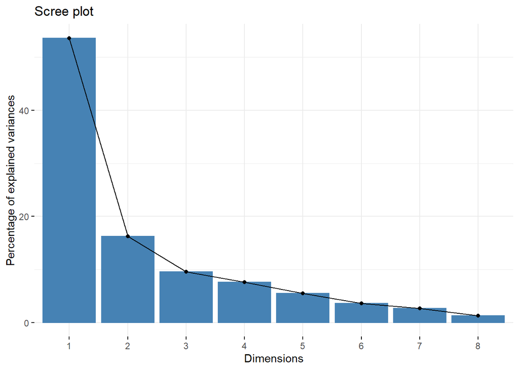

```r
#Visualize eigenvalues
#Scree plot,

fviz_eig(pca_human2)
```

The PCA results for standardised data are are different from unstandardized data.

PCA on standardised data are easier to interprete and see the cooreltion as compared to unstandardised data.

Based on these results

The PC1 account for 53.6% of the total variance and the PC2 16.2%. Thus PC1 and PC2 contributes about 69% of the total variation in the dataset and have eigenvalues > 1 This mean, PC1 and PC2 provides a good approximation of the variation present in the original human dataset that has 8 variable.

```r
# create and print out a summary of pca_human
s <- summary(pca_human2)

# rounded percentages of variance captured by each PC
pca_pr <- round(100*s$importance[2,], digits = 1)

# print out the percentages of variance
pca_pr
```

```
##  PC1  PC2  PC3  PC4  PC5  PC6  PC7  PC8
## 53.6 16.2  9.6  7.6  5.5  3.6  2.6  1.3
```

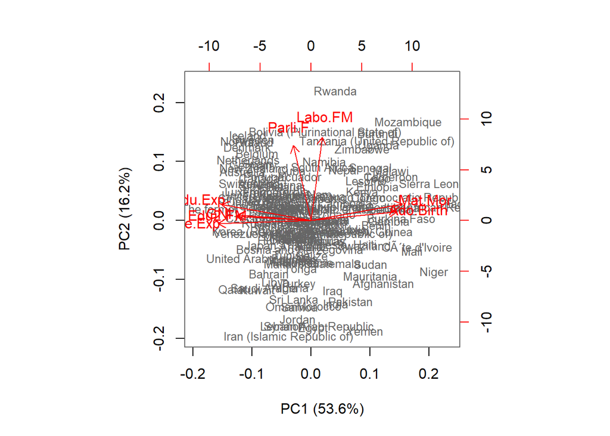

```r
# create object pc_lab to be used as axis labels
pc_lab <- paste0(names(pca_pr), " (", pca_pr, "%)")

# draw a biplot of the principal component representation and the original variables
biplot(pca_human2, cex = c(0.8, 1), col = c("grey40", "red"), xlab = pc_lab[1], ylab = pc_lab[2])
```

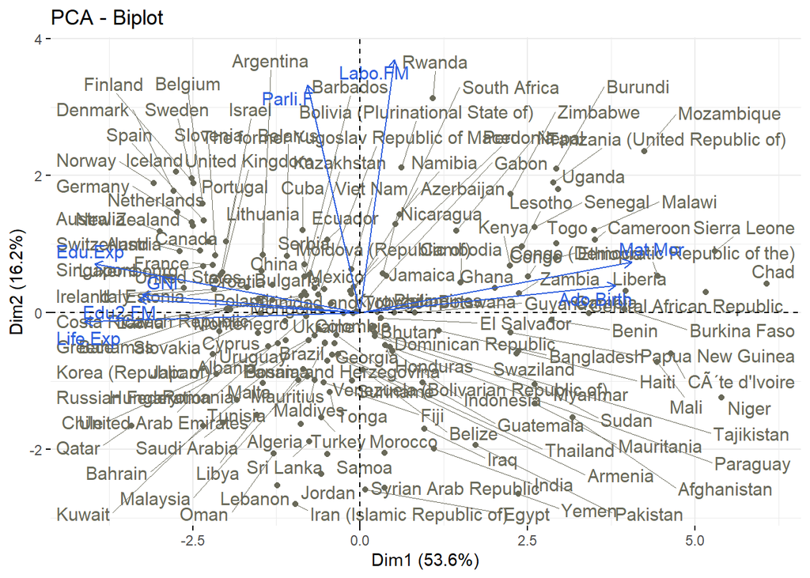

```r
# Anothe way to draw a biplot of the principal component
# Gives percentage variance of PC1 on the x axis and PC2 on the y axis
fviz_pca_biplot(pca_human2, repel = TRUE, col.var = "#2E5FDF", # Variables color
                col.ind = "#696959"  # Individuals color
                )
```

# **Multiple Correspondence Analysis**

```r
# Import data
# Loading FactoMineR
library(FactoMineR)
```

```r
library (ggplot2)
library(dplyr)
library(tidyr)
#Load Tea data
data(tea)

# the structure and
str(tea)
```

```
## 'data.frame':    300 obs. of  36 variables:
##  $ breakfast       : Factor w/ 2 levels "breakfast","Not.breakfast": 1 1 2 2 1 2 1 2 1 1 ...
##  $ tea.time        : Factor w/ 2 levels "Not.tea time",..: 1 1 2 1 1 1 2 2 2 1 ...
##  $ evening         : Factor w/ 2 levels "evening","Not.evening": 2 2 1 2 1 2 2 1 2 1 ...
##  $ lunch           : Factor w/ 2 levels "lunch","Not.lunch": 2 2 2 2 2 2 2 2 2 2 ...
##  $ dinner          : Factor w/ 2 levels "dinner","Not.dinner": 2 2 1 1 2 1 2 2 2 2 ...
##  $ always          : Factor w/ 2 levels "always","Not.always": 2 2 2 2 1 2 2 2 2 2 ...
##  $ home            : Factor w/ 2 levels "home","Not.home": 1 1 1 1 1 1 1 1 1 1 ...
##  $ work            : Factor w/ 2 levels "Not.work","work": 1 1 2 1 1 1 1 1 1 1 ...
##  $ tearoom         : Factor w/ 2 levels "Not.tearoom",..: 1 1 1 1 1 1 1 1 1 2 ...
##  $ friends         : Factor w/ 2 levels "friends","Not.friends": 2 2 1 2 2 2 1 2 2 2 ...
##  $ resto           : Factor w/ 2 levels "Not.resto","resto": 1 1 2 1 1 1 1 1 1 1 ...
##  $ pub             : Factor w/ 2 levels "Not.pub","pub": 1 1 1 1 1 1 1 1 1 1 ...
##  $ Tea             : Factor w/ 3 levels "black","Earl Grey",..: 1 1 2 2 2 2 2 1 2 1 ...
##  $ How             : Factor w/ 4 levels "alone","lemon",..: 1 3 1 1 1 1 1 3 3 1 ...
```

[output cut: 22 more lines]

```r
#the dimensions
dim(tea)
```

```
## [1] 300  36
```

Tes sata is data frame (of factors) containing the answers of a questionnaire on tea consumption 300 individuals.

We consider the following columns to answer the following:

The kind of tea taken How the tea is taken (alone, w/milk, w/lemon, other) Form of tea used either tea bags, loose tea or both If sugar is used or not Where the tea is bought either the supermarket, shops, both)

```r
# select columns of interest
new_tea = tea[, c("Tea", "How", "how", "sugar", "where")]
# take a look
head(new_tea)
```

```
##         Tea   How     how    sugar       where
## 1     black alone tea bag    sugar chain store
## 2     black  milk tea bag No.sugar chain store
## 3 Earl Grey alone tea bag No.sugar chain store
## 4 Earl Grey alone tea bag    sugar chain store
## 5 Earl Grey alone tea bag No.sugar chain store
## 6 Earl Grey alone tea bag No.sugar chain store
```

Perform MCA

```r
# apply MCA
mca = MCA(new_tea, graph = FALSE)
```

Visualization and interpretation

```r
# table of eigenvalues
mca$eig
```

```
##        eigenvalue percentage of variance cumulative percentage of variance
## dim 1  0.33524490              16.762245                          16.76225
## dim 2  0.30882623              15.441311                          32.20356
## dim 3  0.25731837              12.865918                          45.06947
## dim 4  0.22361328              11.180664                          56.25014
## dim 5  0.19847072               9.923536                          66.17367
## dim 6  0.18376817               9.188408                          75.36208
## dim 7  0.17249065               8.624533                          83.98662
## dim 8  0.14061618               7.030809                          91.01742
## dim 9  0.10497110               5.248555                          96.26598
## dim 10 0.07468041               3.734020                         100.00000
```

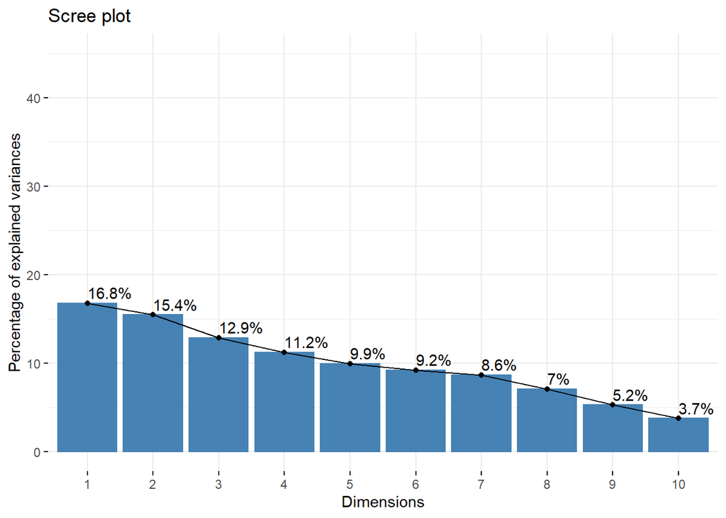

```r
# Plot the eigenvalues
fviz_screeplot(mca, addlabels = TRUE, ylim = c(0, 45))
```

```r
# column coordinates
head(mca$var$coord)
```

```
##                 Dim 1       Dim 2       Dim 3      Dim 4       Dim 5
## black      0.47312391  0.19818117  1.04520460  0.8545399 -0.05679483
## Earl Grey -0.26470789  0.08752788 -0.46234972 -0.1085081 -0.17380989
## green      0.48719553 -0.95631175  0.36025321 -1.2816332  1.14388262
## alone     -0.01717551 -0.25058466  0.14995925 -0.4537372 -0.37775314
## lemon      0.66773816  0.45841522 -1.56133820  0.6258549 -0.36140930
## milk      -0.33762633  0.22018465  0.09285414  0.7795371  1.64433688
```

```r
# row coordinates
head(mca$ind$coord)
```

```
##        Dim 1       Dim 2      Dim 3        Dim 4      Dim 5
## 1 -0.3247111 -0.28824408  0.3046764  0.410521793 -0.2583797
## 2 -0.2589356 -0.07366063  0.7886356  0.691935987  0.6427508
## 3 -0.4031078 -0.28291032  0.2167659 -0.236981750 -0.3175646
## 4 -0.5795738 -0.32806738 -0.2897083  0.003208004 -0.3109117
## 5 -0.4031078 -0.28291032  0.2167659 -0.236981750 -0.3175646
## 6 -0.4031078 -0.28291032  0.2167659 -0.236981750 -0.3175646
```

The results displays the coordinates of each variable categories in each dimension

To visualize the correlation between variables and MCA principal dimensions

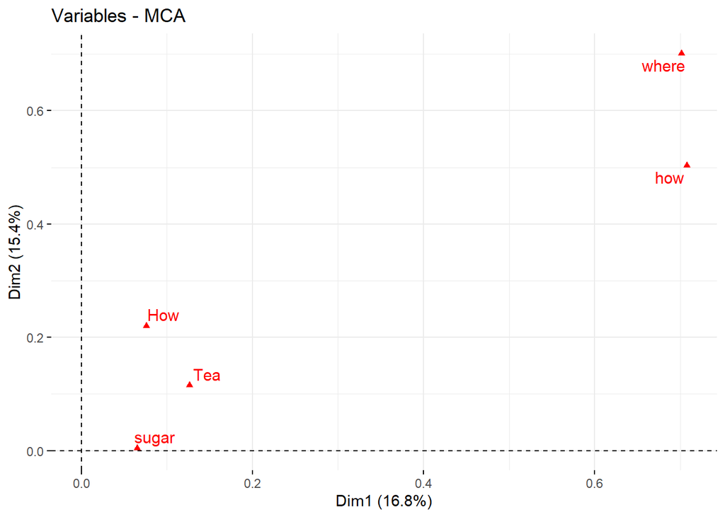

```r
# row coordinates
fviz_mca_var(mca, choice = "mca.cor",
            repel = TRUE, # Avoid text overlapping (slow)
            ggtheme = theme_minimal())
```

The plot above helps to assess the variables that are the most correlated with each of the dimension. The squared correlations between variables and the dimensions are used as coordinates.

Note How- how the tea is taken (alone, w/milk, w/lemon, other) how- Form of tea used either tea bags, loose tea or both If sugar is used or not Where- where the tea is bought either the supermarket, shops, both)

Additional plots

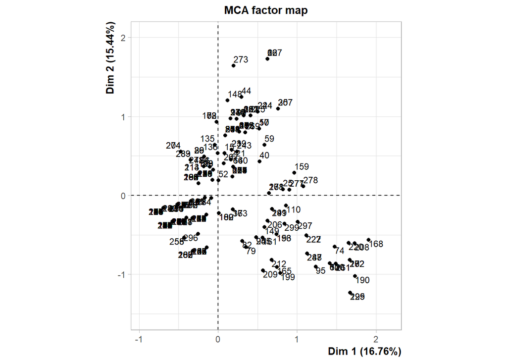

```r
plot.MCA(mca, invisible=c("var","quali.sup"), cex=0.8)
```

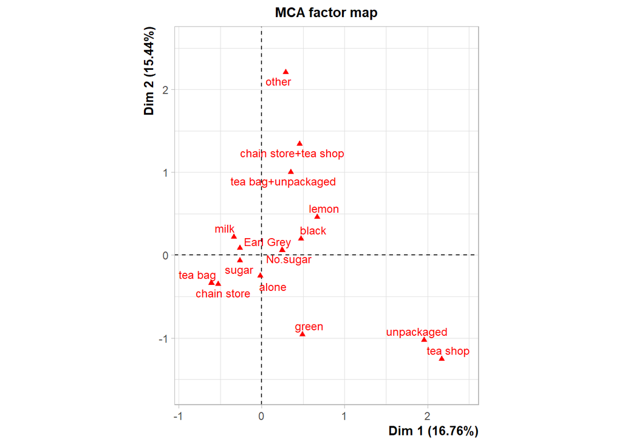

```r
plot.MCA(mca, invisible=c("ind","quali.sup"), cex=0.8)
```